# DGE_WTvsdelta_37C_30C_thesis

Rachael Murray

2025-03-03

# Summary

Differential Gene Expression WT vs delta at 37°C and WT vs delta at 30°C in YPD samples, using DESeq2

This analysis produces files:

- `deseq_df_WTvsdelta_37C_YPD.txt`
- `deglist_WTvsdelta_37C_YPD_up2x_FDR5.txt`
- `deglist_WTvsdelta_37C_YPD_down2x_FDR5.txt`
- `deseq_df_WTvsdelta_30C_YPD.txt`
- `deglist_WTvsdelta_30C_YPD_up2x_FDR5.txt`
- `deglist_WTvsdelta_30C_YPD_down2x_FDR5.txt`

This analysis produces figures:

Conclusions: - Significant differential gene expression between WT and delta samples at both 30°C and 37°C

- Many genes up-regulated in flc1∆ are cell wall biosynthesis genes, membrane transporters, transcription factors

# WT vs delta at 37°C

## Load count data from shared script load_count_data.Rmd

# Load and organise count data

`load_count_data.Rmd` is just to load and organise the raw count data in R, as well as loading libraries for data analysis. Other scripts can just run this one instead of duplicating code, especially scripts for differential gene expression analysis.

This runs *after* `QC_PCA.Rmd`, which does the organisation. This just loads the organised counts from the file `results/summaries/counts_bysamplecode.txt`.

## Load the organised counts

```r
counts_all <-
  here::here("results", "summaries", "counts_bysamplecode.txt") %>%
  readr::read_tsv(comment = "#",
                  col_types = "ciiiiiiiiiiiiiiiiiiiiiiiiiiiiiii")   %>%
  magrittr::set_rownames(.$Gene)
counts_all
```

```
## # A tibble: 6,795 × 32
##    Gene       Length WT_30_Y_1 WT_30_Y_2 WT_30_Y_3 FL_30_Y_1 FL_30_Y_2 FL_30_Y_3
##  * <chr>       <int>     <int>     <int>     <int>     <int>     <int>     <int>
##  1 CNAG_00002   1027       322       378       346       310       309       174
##  2 CNAG_00003   2397        19        43        27        54        52        33
##  3 CNAG_00004   3424        94        80        83       102        94        65
##  4 CNAG_00005   2162       462       399       385       378       344       310
##  5 CNAG_00006   1450      1019      1533      1256      1505      1359       778
##  6 CNAG_00007   2294       471       703       579       476       407       284
##  7 CNAG_00008   4351       141       226       206       272       259       164
##  8 CNAG_00009   1794       160       162       187       323       250       171
##  9 CNAG_00010   3879       195       199       242       362       272       159
## 10 CNAG_00011   2037        85       117       114       162       139        81
## # ℹ 6,785 more rows
## # ℹ 24 more variables: WT_37_Y_1 <int>, WT_37_Y_2 <int>, WT_37_Y_3 <int>,
## #   FL_37_Y_1 <int>, FL_37_Y_2 <int>, FL_37_Y_3 <int>, WT_37_C_1 <int>,
## #   WT_37_C_2 <int>, WT_37_C_3 <int>, FL_37_C_1 <int>, FL_37_C_2 <int>,
## #   FL_37_C_3 <int>, WT_37_E_1 <int>, WT_37_E_2 <int>, WT_37_E_3 <int>,
## #   FL_37_E_1 <int>, FL_37_E_2 <int>, FL_37_E_3 <int>, WT_37_CE_1 <int>,
## #   WT_37_CE_2 <int>, WT_37_CE_3 <int>, FL_37_CE_1 <int>, FL_37_CE_2 <int>, …
```

## Load the sample sheet

```r
sample_sheet <-
  here::here("input", "experiment",
             "CryptoRNAseqFLC1SampleKey.csv") %>%
  readr::read_csv(comment = "#", col_types = "ccccccc") %>%
  dplyr::mutate(Condition = stringr::str_sub(SampleName,start = 1L, end = -3L)) %>%
  dplyr::transmute(SampleID = as_factor(SampleID),
                   SampleName = as_factor(SampleName),
                   Condition = as_factor(Condition),
                   FLC1 = factor(FLC1, levels = c("delta", "WT")),
                   Temperature = factor(Temperature, levels = c("30", "37")),
                   Media = as_factor(Media),
                   BioRep = as_factor(BioRep))

sample_sheet
```

```
## # A tibble: 30 × 7
##    SampleID SampleName Condition FLC1  Temperature Media BioRep
##    <fct>    <fct>      <fct>     <fct> <fct>       <fct> <fct>
##  1 1        WT_30_Y_1  WT_30_Y   WT    30          YPD   1
##  2 2        WT_30_Y_2  WT_30_Y   WT    30          YPD   2
##  3 3        WT_30_Y_3  WT_30_Y   WT    30          YPD   3
##  4 4        FL_30_Y_1  FL_30_Y   delta 30          YPD   1
##  5 5        FL_30_Y_2  FL_30_Y   delta 30          YPD   2
##  6 6        FL_30_Y_3  FL_30_Y   delta 30          YPD   3
##  7 7        WT_37_Y_1  WT_37_Y   WT    37          YPD   1
##  8 8        WT_37_Y_2  WT_37_Y   WT    37          YPD   2
##  9 9        WT_37_Y_3  WT_37_Y   WT    37          YPD   3
## 10 10       FL_37_Y_1  FL_37_Y   delta 37          YPD   1
## # ℹ 20 more rows
```

## Load H99 Gene information

```r
gene_info_df <-
  here::here("input", "annotation",
             "H99_geneinfo_FungiDB59.txt") %>%
  readr::read_tsv(comment = "#")  %>%
  dplyr::rename(gene = GeneID, geneName = GeneName)
```

## DESeq on a subset of data, only 37C in YPD

```r
sample_sheet_WTvsdelta_37C_YPD <-
  dplyr::filter(sample_sheet,
                Temperature == "37", Media == "YPD")

dds_WTvsdelta_37C_YPD <-
  DESeqDataSetFromMatrix(
    countData = counts_all %>%
      dplyr::select(sample_sheet_WTvsdelta_37C_YPD$SampleName) %>%
      magrittr::set_rownames(counts_all$Gene),
    colData = sample_sheet_WTvsdelta_37C_YPD,
    design = ~ FLC1) %>%
  DESeq()
dds_WTvsdelta_37C_YPD
```

```
## class: DESeqDataSet
## dim: 6795 6
## metadata(1): version
## assays(4): counts mu H cooks
## rownames(6795): CNAG_00002 CNAG_00003 ... CNAG_14001 CNAG_14002
## rowData names(22): baseMean baseVar ... deviance maxCooks
## colnames(6): WT_37_Y_1 WT_37_Y_2 ... FL_37_Y_2 FL_37_Y_3
## colData names(8): SampleID SampleName ... BioRep sizeFactor
```

```r
results(dds_WTvsdelta_37C_YPD)
```

```
## log2 fold change (MLE): FLC1 WT vs delta
## Wald test p-value: FLC1 WT vs delta
## DataFrame with 6795 rows and 6 columns
##             baseMean log2FoldChange     lfcSE       stat    pvalue      padj
##            <numeric>      <numeric> <numeric>  <numeric> <numeric> <numeric>
## CNAG_00002  445.3210     -0.0131039 0.1320603 -0.0992263 0.9209586  0.941903
## CNAG_00003   49.4729     -0.4829406 0.2730471 -1.7687077 0.0769427  0.128320
## CNAG_00004  107.5711      0.2423738 0.1890020  1.2823875 0.1997068  0.286034
## CNAG_00005  666.9180     -0.0198152 0.1245374 -0.1591104 0.8735819  0.909723
## CNAG_00006 1677.6572      0.1564381 0.0890361  1.7570196 0.0789145  0.131083
## ...              ...            ...       ...        ...       ...       ...
## CNAG_08027 333.77309     -0.3061507  0.132725  -2.306663 0.0210736  0.042386
## CNAG_08028 111.24722     -0.2633673  0.186173  -1.414638 0.1571747  0.234769
## CNAG_08029 107.44692      0.1728125  0.196800   0.878111 0.3798837  0.480572
## CNAG_14001 414.87927     -0.0445938  0.131145  -0.340033 0.7338315  0.799746
## CNAG_14002   1.24495     -1.1303981  1.635258  -0.691266 0.4893985  0.587557
```

```r
resultsNames(dds_WTvsdelta_37C_YPD)
```

```
## [1] "Intercept"        "FLC1_WT_vs_delta"
```

```r
deseq_df_WTvsdelta_37C_YPD <-
  biobroom::tidy.DESeqDataSet(dds_WTvsdelta_37C_YPD) %>%
  dplyr::filter(term == "FLC1_WT_vs_delta") %>%
  dplyr::left_join(gene_info_df,
                   by = "gene") %>%
  dplyr::select(gene,
                geneName,
                baseMean,
                log2FC = estimate,
                stderror,
                padj = p.adjusted)
```

### List DEGs most UP in WT vs delta

We cut off at 2x changes with 5% FDR here.

```r
# Make data frames of DEGs up and down, arranged by log2FC
DEGdf_WT_up2x_FDR5_37 <-
  dplyr::filter(deseq_df_WTvsdelta_37C_YPD,
                log2FC > 1, padj < 0.05) %>%
  dplyr::arrange(desc(log2FC))
print(DEGdf_WT_up2x_FDR5_37, n = 20)
```

```
## # A tibble: 40 × 6
##    gene       geneName baseMean log2FC stderror     padj
##    <chr>      <chr>       <dbl>  <dbl>    <dbl>    <dbl>
##  1 CNAG_04283 <NA>        247.    9.77   1.03   7.56e-20
##  2 CNAG_03454 <NA>         65.7   1.94   0.618  4.61e- 3
##  3 CNAG_04469 <NA>         88.6   1.82   0.544  2.50e- 3
##  4 CNAG_07695 <NA>        123.    1.51   0.187  1.28e-14
##  5 CNAG_00987 <NA>        380.    1.39   0.133  8.95e-24
##  6 CNAG_04901 <NA>        250.    1.28   0.173  1.71e-12
##  7 CNAG_05144 CAN2       1327.    1.25   0.109  9.21e-29
##  8 CNAG_00904 <NA>         20.0   1.24   0.413  6.95e- 3
##  9 CNAG_00409 <NA>        200.    1.23   0.170  4.66e-12
## 10 CNAG_06096 <NA>       1440.    1.22   0.121  1.70e-22
## 11 CNAG_05340 <NA>         36.6   1.20   0.313  4.49e- 4
## 12 CNAG_03892 <NA>      25143.    1.20   0.100  3.69e-31
## 13 CNAG_00935 <NA>       3176.    1.20   0.142  8.06e-16
## 14 CNAG_01577 <NA>       5183.    1.17   0.101  5.02e-29
## 15 CNAG_04799 <NA>      32148.    1.16   0.103  1.24e-27
## 16 CNAG_03891 <NA>      38325.    1.16   0.0884 1.95e-37
## 17 CNAG_07558 <NA>      13216.    1.14   0.113  2.80e-22
## 18 CNAG_01592 STE14        93.5   1.13   0.235  7.69e- 6
## 19 CNAG_03664 NIC1        434.    1.12   0.127  2.91e-17
## 20 CNAG_04467 <NA>        247.    1.12   0.165  1.19e-10
## # ℹ 20 more rows
```

Print the top 20 *named* DEGs

```r
DEGdf_WT_up2x_FDR5_37 %>%
  dplyr::filter(!is.na(geneName)) %>%
  print(n = 20)
```

```
## # A tibble: 4 × 6
##   gene       geneName baseMean log2FC stderror     padj
##   <chr>      <chr>       <dbl>  <dbl>    <dbl>    <dbl>
## 1 CNAG_05144 CAN2       1327.    1.25    0.109 9.21e-29
## 2 CNAG_01592 STE14        93.5   1.13    0.235 7.69e- 6
## 3 CNAG_03664 NIC1        434.    1.12    0.127 2.91e-17
## 4 CNAG_02460 HEM13       230.    1.09    0.150 4.43e-12
```

### List DEGs most DOWN in WT vs delta

```r
# Make data frames of DEGs up and down, arranged by log2FC
DEGdf_WT_down2x_FDR5_37 <-
  dplyr::filter(deseq_df_WTvsdelta_37C_YPD,
                log2FC < -1, padj < 0.05) %>%
  dplyr::arrange(log2FC)
print(DEGdf_WT_down2x_FDR5_37, n = 20)
```

```
## # A tibble: 610 × 6
##    gene       geneName baseMean log2FC stderror      padj
##    <chr>      <chr>       <dbl>  <dbl>    <dbl>     <dbl>
##  1 CNAG_04891 <NA>      2814.    -8.73    0.278 3.05e-213
##  2 CNAG_05075 <NA>        71.5   -5.91    0.620 4.55e- 20
##  3 CNAG_02734 <NA>         8.79  -5.36    1.27  1.08e-  4
##  4 CNAG_02526 <NA>        97.0   -5.34    0.452 1.40e- 30
##  5 CNAG_01272 <NA>     17289.    -5.08    0.116 0
##  6 CNAG_01960 <NA>      2539.    -5.00    0.138 9.44e-286
##  7 CNAG_05662 PTP1        90.4   -4.81    0.399 1.06e- 31
##  8 CNAG_01121 <NA>      2987.    -4.70    0.123 0
##  9 CNAG_01954 <NA>       107.    -4.66    0.366 2.62e- 35
## 10 CNAG_02217 CHS7       973.    -4.52    0.156 1.18e-182
## 11 CNAG_02934 <NA>       290.    -4.47    0.221 8.74e- 89
## 12 CNAG_00588 <NA>       250.    -4.37    0.237 7.87e- 74
## 13 CNAG_01052 <NA>       291.    -4.20    0.204 2.80e- 92
## 14 CNAG_01560 <NA>         3.89  -4.13    1.40  7.91e-  3
## 15 CNAG_03224 <NA>        53.9   -4.11    0.440 2.32e- 19
## 16 CNAG_04735 MEP1      1672.    -4.07    0.131 1.33e-209
## 17 CNAG_00749 <NA>        37.7   -4.06    0.502 1.12e- 14
## 18 CNAG_05916 <NA>        51.8   -4.05    0.447 3.17e- 18
## 19 CNAG_04142 <NA>       462.    -4.05    0.179 4.16e-111
## 20 CNAG_03782 <NA>         6.77  -4.04    1.18  1.81e-  3
## # ℹ 590 more rows
```

Print the top 20 *named* DEGs

```r
DEGdf_WT_down2x_FDR5_37 %>%
  dplyr::filter(!is.na(geneName)) %>%
  print(n = 20)
```

```
## # A tibble: 97 × 6
##    gene       geneName baseMean log2FC stderror      padj
##    <chr>      <chr>       <dbl>  <dbl>    <dbl>     <dbl>
##  1 CNAG_05662 PTP1        90.4   -4.81    0.399 1.06e- 31
##  2 CNAG_02217 CHS7       973.    -4.52    0.156 1.18e-182
##  3 CNAG_04735 MEP1      1672.    -4.07    0.131 1.33e-209
##  4 CNAG_00979 CTR4      1988.    -3.83    0.311 4.41e- 33
##  5 CNAG_06347 BLP2      7929.    -3.67    0.119 1.41e-204
##  6 CNAG_01446 HSP12     6534.    -3.25    0.105 4.34e-206
##  7 CNAG_05377 ITR3        42.7   -3.23    0.405 2.62e- 14
##  8 CNAG_01562 BLP4     46184.    -3.10    0.107 4.95e-181
##  9 CNAG_06346 BLP1       149.    -2.83    0.221 7.53e- 36
## 10 CNAG_00654 SRX1       242.    -2.82    0.185 1.93e- 50
## 11 CNAG_04681 LPI14      558.    -2.64    0.129 1.82e- 90
## 12 CNAG_02225 EXG104     101.    -2.61    0.245 5.61e- 25
## 13 CNAG_06052 GAL7       113.    -2.60    0.231 8.45e- 28
## 14 CNAG_03385 PCL103    2727.    -2.54    0.483 8.53e-  7
## 15 CNAG_05067 CLR5         9.27  -2.54    0.728 1.54e-  3
## 16 CNAG_03498 FRE201      82.1   -2.53    0.277 1.81e- 18
## 17 CNAG_04016 ISP5       107.    -2.48    0.227 3.08e- 26
## 18 CNAG_05381 ITR3C       35.3   -2.46    0.377 6.43e- 10
## 19 CNAG_06031 KRE63      115.    -2.37    0.220 1.59e- 25
## 20 CNAG_02008 OVA1     28768.    -2.31    0.311 1.35e- 12
## # ℹ 77 more rows
```

```r
plot_labels_down <- DEGdf_WT_down2x_FDR5_37 %>%
  dplyr::filter(!is.na(geneName))
```

### Volcano plot of DEGs

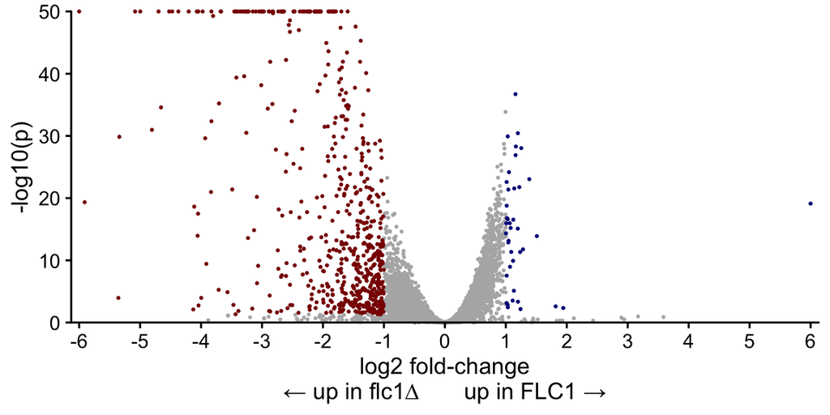

```r
volcano_WTvsdelta_37C_YPD <-
  ggplot(data = deseq_df_WTvsdelta_37C_YPD,
         aes(x = log2FC, y = -log10(padj)) ) +
  geom_point(size = 0.3, colour = "grey70") +
  geom_point(data = DEGdf_WT_up2x_FDR5_37,
             size = 0.3, colour = "darkblue") +
  geom_point(data = DEGdf_WT_down2x_FDR5_37,
             size = 0.3, colour = "darkred") +
  #geom_text_repel(data = plot_labels_down, aes(label = geneName), size = 3, colour = "darkred") +
  scale_y_continuous("-log10(p)",
                     limits = c(0,50), expand = c(0,0),
                     oob=scales::squish) +
  scale_x_continuous("log2 fold-change\n← up in flc1∆       up in FLC1 →",
                     breaks = -6:6,
                     limits = c(-6,6), expand = c(0.01,0.01),
                     oob = scales::squish) +
  coord_cartesian(clip = "off")

volcano_WTvsdelta_37C_YPD
```

```r
#ggsave(here("WTvsDelta_37_YPD_volcano.png"), volcano_WTvsdelta_37C_YPD , width = 4, height = 3)
```

The volcano plot shows extensive differential gene expression, with more genes substantially down in WT (i.e. up in FLC1∆).

### Write outputs to files

```r
deseq_df_WTvsdelta_37C_YPD %>%
  dplyr::mutate(
    across(c(baseMean, log2FC, stderror), round, digits = 3)
  ) %>%
  dplyr::mutate(padj = signif(padj, digits = 4)) %>%
  write_tsv(file = here::here("results", "DEGs",
                              "deseq_df_WTvsdelta_37C_YPD.txt"))
```

```r
DEGdf_WT_up2x_FDR5_37 %>%
  dplyr::pull(gene) %>%
  write_lines(file = here::here("results", "DEGs",
                            "deglist_WTvsdelta_37C_YPD_up2x_FDR5.txt"))

DEGdf_WT_down2x_FDR5_37 %>%
  dplyr::pull(gene) %>%
  write_lines(file = here::here("results", "DEGs",
                            "deglist_WTvsdelta_37C_YPD_down2x_FDR5.txt"))
```

# WT vs delta at 30°C

## DESeq on a subset of data, only 30C in YPD

```r
sample_sheet_WTvsdelta_30C_YPD <-
  dplyr::filter(sample_sheet,
                Temperature == "30", Media == "YPD")

dds_WTvsdelta_30C_YPD <-
  DESeqDataSetFromMatrix(
    countData = counts_all %>%
      dplyr::select(sample_sheet_WTvsdelta_30C_YPD$SampleName) %>%
      magrittr::set_rownames(counts_all$Gene),
    colData = sample_sheet_WTvsdelta_30C_YPD,
    design = ~ FLC1) %>%
  DESeq()
dds_WTvsdelta_30C_YPD
```

```
## class: DESeqDataSet
## dim: 6795 6
## metadata(1): version
## assays(4): counts mu H cooks
## rownames(6795): CNAG_00002 CNAG_00003 ... CNAG_14001 CNAG_14002
## rowData names(22): baseMean baseVar ... deviance maxCooks
## colnames(6): WT_30_Y_1 WT_30_Y_2 ... FL_30_Y_2 FL_30_Y_3
## colData names(8): SampleID SampleName ... BioRep sizeFactor
```

```r
results(dds_WTvsdelta_30C_YPD)
```

```
## log2 fold change (MLE): FLC1 WT vs delta
## Wald test p-value: FLC1 WT vs delta
## DataFrame with 6795 rows and 6 columns
##              baseMean log2FoldChange     lfcSE       stat      pvalue
##             <numeric>      <numeric> <numeric>  <numeric>   <numeric>
## CNAG_00002   304.2629       0.600187  0.163761   3.665012 0.000247327
## CNAG_00003    36.7405      -0.469196  0.336317  -1.395100 0.162985691
## CNAG_00004    85.9937       0.171813  0.240174   0.715368 0.474381446
## CNAG_00005   385.9369       0.421829  0.205504   2.052655 0.040106076
## CNAG_00006  1214.7328       0.263007  0.147334   1.785113 0.074242999
## ...               ...            ...       ...        ...         ...
## CNAG_08027 170.021816      -0.327187  0.192547 -1.6992550   0.0892712
## CNAG_08028  60.318903      -0.134385  0.289322 -0.4644806   0.6423035
## CNAG_08029  78.841107       0.146733  0.244746  0.5995330   0.5488175
## CNAG_14001 376.399451      -0.281509  0.172404 -1.6328487   0.1025008
## CNAG_14002   0.284371       0.156000  3.215062  0.0485215   0.9613007
##                  padj
##             <numeric>
## CNAG_00002 0.00107175
## CNAG_00003 0.26828297
## CNAG_00004 0.60524529
## CNAG_00005 0.08740082
## CNAG_00006 0.14391172
## ...               ...
## CNAG_08027   0.166709
## CNAG_08028   0.749338
## CNAG_08029   0.671098
## CNAG_14001   0.185798
## CNAG_14002   0.974720
```

```r
resultsNames(dds_WTvsdelta_30C_YPD)
```

```
## [1] "Intercept"        "FLC1_WT_vs_delta"
```

```r
deseq_df_WTvsdelta_30C_YPD <-
  biobroom::tidy.DESeqDataSet(dds_WTvsdelta_30C_YPD) %>%
  dplyr::filter(term == "FLC1_WT_vs_delta") %>%
  dplyr::left_join(gene_info_df,
                   by = "gene") %>%
  dplyr::select(gene,
                geneName,
                baseMean,
                log2FC = estimate,
                stderror,
                padj = p.adjusted)
```

### List DEGs most UP in WT vs delta

We cut off at 2x changes with 5% FDR here.

```r
# Make data frames of DEGs up and down, arranged by log2FC
DEGdf_WT_up2x_FDR5_30 <-
  dplyr::filter(deseq_df_WTvsdelta_30C_YPD,
                log2FC > 1, padj < 0.05) %>%
  dplyr::arrange(desc(log2FC))
print(DEGdf_WT_up2x_FDR5_30, n = 20)
```

```
## # A tibble: 201 × 6
##    gene       geneName baseMean log2FC stderror     padj
##    <chr>      <chr>       <dbl>  <dbl>    <dbl>    <dbl>
##  1 CNAG_04283 <NA>       184.    11.0     1.19  7.19e-19
##  2 CNAG_03454 <NA>       296.     2.57    0.503 2.64e- 6
##  3 CNAG_07448 DUR3        39.3    2.10    0.363 8.32e- 8
##  4 CNAG_02849 <NA>        12.0    2.08    0.602 2.17e- 3
##  5 CNAG_06298 <NA>        52.8    1.93    0.371 1.75e- 6
##  6 CNAG_03759 <NA>         8.81   1.74    0.697 3.30e- 2
##  7 CNAG_01577 <NA>      4389.     1.67    0.174 5.68e-20
##  8 CNAG_06745 H3       30828.     1.64    0.454 1.30e- 3
##  9 CNAG_00100 <NA>      4380.     1.63    0.231 3.01e-11
## 10 CNAG_07807 <NA>     17358.     1.57    0.517 7.88e- 3
## 11 CNAG_06746 H2B      49406.     1.57    0.490 4.93e- 3
## 12 CNAG_05340 <NA>        25.8    1.56    0.404 5.58e- 4
## 13 CNAG_06747 H2A-1    29224.     1.55    0.244 2.82e- 9
## 14 CNAG_02588 <NA>        19.1    1.54    0.476 4.26e- 3
## 15 CNAG_03891 <NA>     21680.     1.53    0.180 4.31e-16
## 16 CNAG_05059 <NA>      2266.     1.52    0.237 1.79e- 9
## 17 CNAG_06207 <NA>       266.     1.52    0.556 1.83e- 2
## 18 CNAG_04677 <NA>        73.4    1.49    0.297 4.09e- 6
## 19 CNAG_01153 <NA>     13909.     1.48    0.445 3.36e- 3
## 20 CNAG_00672 <NA>     40991.     1.47    0.205 1.60e-11
## # ℹ 181 more rows
```

Print the top 20 *named* DEGs

```r
DEGdf_WT_up2x_FDR5_30 %>%
  dplyr::filter(!is.na(geneName)) %>%
  print(n = 20)
```

```
## # A tibble: 31 × 6
##    gene       geneName   baseMean log2FC stderror     padj
##    <chr>      <chr>         <dbl>  <dbl>    <dbl>    <dbl>
##  1 CNAG_07448 DUR3           39.3   2.10    0.363 8.32e- 8
##  2 CNAG_06745 H3          30828.    1.64    0.454 1.30e- 3
##  3 CNAG_06746 H2B         49406.    1.57    0.490 4.93e- 3
##  4 CNAG_06747 H2A-1       29224.    1.55    0.244 2.82e- 9
##  5 CNAG_05144 CAN2         1642.    1.39    0.169 5.67e-15
##  6 CNAG_06923 XFP2          192.    1.37    0.213 1.96e- 9
##  7 CNAG_00232 RPL30       18902.    1.26    0.152 3.50e-15
##  8 CNAG_06770 FBA1         4421.    1.25    0.174 1.51e-11
##  9 CNAG_05465 GIB2        42115.    1.23    0.188 1.16e- 9
## 10 CNAG_05232 RPL2        51756.    1.21    0.180 2.29e-10
## 11 CNAG_01648 H4          36071.    1.20    0.243 6.07e- 6
## 12 CNAG_06447 RPL17       16190.    1.18    0.150 1.09e-13
## 13 CNAG_06811 RPL22alpha  12875.    1.17    0.141 2.28e-15
## 14 CNAG_00370 UBI1        26197.    1.14    0.159 1.43e-11
## 15 CNAG_05896 UBA2          193.    1.14    0.190 2.61e- 8
## 16 CNAG_00934 DAL1          167.    1.12    0.248 3.76e- 5
## 17 CNAG_04758 AMT2           54.1   1.12    0.328 2.50e- 3
## 18 CNAG_01496 PPT1          275.    1.10    0.218 3.50e- 6
## 19 CNAG_02460 HEM13         143.    1.09    0.210 1.84e- 6
## 20 CNAG_00413 OFD1          697.    1.08    0.202 7.91e- 7
## # ℹ 11 more rows
```

### List DEGs most DOWN in WT vs delta

```r
# Make data frames of DEGs up and down, arranged by log2FC
DEGdf_WT_down2x_FDR5_30 <-
  dplyr::filter(deseq_df_WTvsdelta_30C_YPD,
                log2FC < -1, padj < 0.05) %>%
  dplyr::arrange(log2FC)
print(DEGdf_WT_down2x_FDR5_30, n = 20)
```

```
## # A tibble: 733 × 6
##    gene       geneName baseMean log2FC stderror      padj
##    <chr>      <chr>       <dbl>  <dbl>    <dbl>     <dbl>
##  1 CNAG_04891 <NA>      3787.    -9.04    0.273 2.57e-236
##  2 CNAG_01954 <NA>       200.    -8.58    0.858 6.93e- 22
##  3 CNAG_02526 <NA>       343.    -8.35    0.612 2.35e- 40
##  4 CNAG_04142 <NA>       613.    -6.63    0.332 3.68e- 86
##  5 CNAG_07447 <NA>        13.0   -6.08    2.50  3.82e-  2
##  6 CNAG_03867 <NA>        59.1   -6.06    0.690 5.55e- 17
##  7 CNAG_00588 <NA>       619.    -6.06    0.275 6.50e-105
##  8 CNAG_00269 <NA>       372.    -5.98    0.301 2.87e- 85
##  9 CNAG_05075 <NA>        83.3   -5.87    0.565 1.46e- 23
## 10 CNAG_01052 <NA>       414.    -5.79    0.298 7.08e- 82
## 11 CNAG_03833 <NA>        10.2   -5.76    1.29  5.35e-  5
## 12 CNAG_01272 <NA>     14795.    -5.67    0.159 4.42e-274
## 13 CNAG_05662 PTP1       181.    -5.60    0.384 4.19e- 46
## 14 CNAG_04553 <NA>        16.2   -5.52    1.11  4.81e-  6
## 15 CNAG_02217 CHS7      1027.    -5.51    0.227 1.97e-127
## 16 CNAG_03650 <NA>        79.8   -5.34    0.493 1.42e- 25
## 17 CNAG_00827 <NA>        36.4   -5.26    1.19  5.67e-  5
## 18 CNAG_01446 HSP12     2984.    -5.25    0.214 1.44e-129
## 19 CNAG_06347 BLP2      7291.    -5.25    0.200 3.46e-148
## 20 CNAG_05666 <NA>         3.13  -5.04    1.46  2.25e-  3
## # ℹ 713 more rows
```

Print the top 20 *named* DEGs

```r
DEGdf_WT_down2x_FDR5_30 %>%
  dplyr::filter(!is.na(geneName)) %>%
  print(n = 20)
```

```
## # A tibble: 120 × 6
##    gene       geneName baseMean log2FC stderror      padj
##    <chr>      <chr>       <dbl>  <dbl>    <dbl>     <dbl>
##  1 CNAG_05662 PTP1       181.    -5.60    0.384 4.19e- 46
##  2 CNAG_02217 CHS7      1027.    -5.51    0.227 1.97e-127
##  3 CNAG_01446 HSP12     2984.    -5.25    0.214 1.44e-129
##  4 CNAG_06347 BLP2      7291.    -5.25    0.200 3.46e-148
##  5 CNAG_04735 MEP1      1297.    -4.09    0.204 1.08e- 86
##  6 CNAG_03491 NDX3         1.58  -4.01    1.69  4.44e-  2
##  7 CNAG_04552 ITR1A        3.05  -3.94    1.45  1.93e-  2
##  8 CNAG_03465 LAC1        96.6   -3.64    0.306 1.39e- 30
##  9 CNAG_05258 SMG1      4349.    -3.63    0.248 3.51e- 46
## 10 CNAG_04016 ISP5       139.    -3.41    0.291 8.42e- 30
## 11 CNAG_06524 FRE3         7.75  -3.34    0.915 1.15e-  3
## 12 CNAG_06698 HAD9       203.    -3.33    0.244 2.50e- 40
## 13 CNAG_05377 ITR3        18.8   -3.27    0.586 2.51e-  7
## 14 CNAG_03498 FRE201     142.    -3.16    0.303 9.58e- 24
## 15 CNAG_00036 SEC14-2    150.    -3.13    0.239 3.45e- 37
## 16 CNAG_04837 MLN1         6.67  -3.11    0.933 3.21e-  3
## 17 CNAG_03385 PCL103    2106.    -3.01    0.216 9.27e- 42
## 18 CNAG_00979 CTR4      1598.    -3.00    0.164 6.39e- 72
## 19 CNAG_02877 FZC51      102.    -2.99    0.276 1.60e- 25
## 20 CNAG_02225 EXG104      69.8   -2.96    0.326 4.02e- 18
## # ℹ 100 more rows
```

### Volcano plot of DEGs

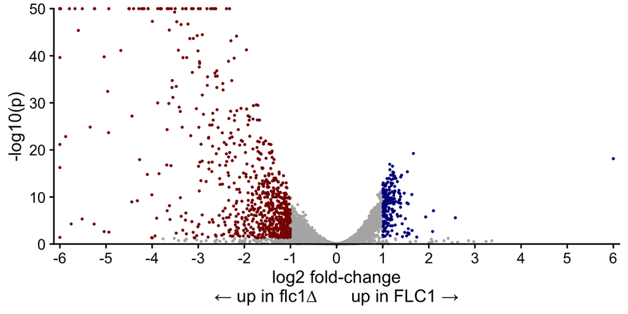

```r
volcano_WTvsdelta_30C_YPD <-
  ggplot(data = deseq_df_WTvsdelta_30C_YPD,
         aes(x = log2FC, y = -log10(padj)) ) +
  geom_point(size = 0.3, colour = "grey70") +
  geom_point(data = DEGdf_WT_up2x_FDR5_30,
             size = 0.3, colour = "darkblue") +
  geom_point(data = DEGdf_WT_down2x_FDR5_30,
             size = 0.3, colour = "darkred") +
scale_y_continuous("-log10(p)",
                     limits = c(0,50), expand = c(0,0),
                     oob=scales::squish) +
  scale_x_continuous("log2 fold-change\n← up in flc1∆       up in FLC1 →",
                     breaks = -6:6,
                     limits = c(-6,6), expand = c(0.01,0.01),
                     oob = scales::squish) +
  coord_cartesian(clip = "off")

volcano_WTvsdelta_30C_YPD
```

```r
ggsave(here("WTvsDelta_30_YPD_volcano.png"), volcano_WTvsdelta_30C_YPD , width = 4, height = 3)
```

The volcano plot shows extensive differential gene expression, with more genes substantially down in WT (i.e. up in FLC1∆).

### Write outputs to files

```r
deseq_df_WTvsdelta_30C_YPD %>%
  dplyr::mutate(
    across(c(baseMean, log2FC, stderror), round, digits = 3)
  ) %>%
  dplyr::mutate(padj = signif(padj, digits = 4)) %>%
  write_tsv(file = here::here("results", "DEGs",
                              "deseq_df_WTvsdelta_30C_YPD.txt"))

DEGdf_WT_up2x_FDR5_30 %>%
  dplyr::pull(gene) %>%
  write_lines(file = here::here("results", "DEGs",
                            "deglist_WTvsdelta_30C_YPD_up2x_FDR5.txt"))

DEGdf_WT_down2x_FDR5_30 %>%
  dplyr::pull(gene) %>%
  write_lines(file = here::here("results", "DEGs",
                            "deglist_WTvsdelta_30C_YPD_down2x_FDR5.txt"))
```

# Top DEG at 30°C and 37°C

```r
FungiDBinfo_WT_down2x_FDR5_30 <- read_csv(
  here("results/DEGs_fungiDB_info/FungiDB_WTvsdelta_30C_YPD_down2x_FDR5.csv")
) %>%
  janitor::clean_names() %>%
  select(
    gene_id, product_description, interpro_id, interpro_description, curated_go_processes, curated_go_functions, curated_go_components, computed_go_processes, computed_go_functions, computed_go_components
  ) %>%
  dplyr::rename(gene = gene_id) %>%
  left_join(
    DEGdf_WT_down2x_FDR5_30,
  )
FungiDBinfo_WT_down2x_FDR5_30 %>%
  slice_head(n = 20)
```

```
## # A tibble: 20 × 15
##    gene       product_description               interpro_id interpro_description
##    <chr>      <chr>                             <chr>       <chr>
##  1 CNAG_04891 hypothetical protein              IPR000772;… Ricin B, lectin dom…
##  2 CNAG_01954 aldo-keto reductase               IPR023210;… NADP-dependent oxid…
##  3 CNAG_02526 hypothetical protein              N/A         N/A
##  4 CNAG_04142 tartrate transporter              IPR011701;… Major facilitator s…
##  5 CNAG_07447 hypothetical protein              N/A         N/A
##  6 CNAG_03867 hypothetical protein              N/A         N/A
##  7 CNAG_00588 hypothetical protein              IPR000772;… Ricin B, lectin dom…
##  8 CNAG_00269 Sorbitol dehydrogenase            IPR002328;… Alcohol dehydrogena…
##  9 CNAG_05075 solute carrier family 20 (sodium… IPR001204   Phosphate transport…
## 10 CNAG_01052 hypothetical protein              N/A         N/A
## 11 CNAG_03833 hypothetical protein              N/A         N/A
## 12 CNAG_01272 hypothetical protein              N/A         N/A
## 13 CNAG_05662 Polyol transporter protein 1      IPR003663;… Sugar/inositol tran…
## 14 CNAG_04553 hypothetical protein              IPR002347;… Short-chain dehydro…
## 15 CNAG_02217 Chitin synthase                   IPR004834;… Fungal chitin synth…
## 16 CNAG_03650 hypothetical protein              N/A         N/A
## 17 CNAG_00827 ribose 5-phosphate isomerase      IPR003500;… Sugar-phosphate iso…
## 18 CNAG_01446 heat shock protein, 12Kda         IPR007250   Heat shock protein …
## 19 CNAG_06347 pr4/barwin domain protein         IPR036908   RlpA-like domain su…
## 20 CNAG_05666 hypothetical protein              N/A         N/A
## # ℹ 11 more variables: curated_go_processes <chr>, curated_go_functions <chr>,
## #   curated_go_components <chr>, computed_go_processes <chr>,
## #   computed_go_functions <chr>, computed_go_components <chr>, geneName <chr>,
## #   baseMean <dbl>, log2FC <dbl>, stderror <dbl>, padj <dbl>
```

```r
FungiDBinfo_WT_down2x_FDR5_37 <- read_csv(
  here("results/DEGs_fungiDB_info/FungiDB_WTvsdelta_37C_YPD_down2x_FDR5.csv")
) %>%
  janitor::clean_names() %>%
  select(
    gene_id, product_description, interpro_id, interpro_description, curated_go_processes, curated_go_functions, curated_go_components, computed_go_processes, computed_go_functions, computed_go_components
  ) %>%
  dplyr::rename(gene = gene_id) %>%
  left_join(
    DEGdf_WT_down2x_FDR5_37,
  )
FungiDBinfo_WT_down2x_FDR5_37 %>%
  slice_head(n = 20)
```

```
## # A tibble: 20 × 15
##    gene       product_description               interpro_id interpro_description
##    <chr>      <chr>                             <chr>       <chr>
##  1 CNAG_04891 hypothetical protein              IPR000772;… Ricin B, lectin dom…
##  2 CNAG_05075 solute carrier family 20 (sodium… IPR001204   Phosphate transport…
##  3 CNAG_02734 hypothetical protein              IPR036291   NAD(P)-binding doma…
##  4 CNAG_02526 hypothetical protein              N/A         N/A
##  5 CNAG_01272 hypothetical protein              N/A         N/A
##  6 CNAG_01960 efflux protein EncT               IPR011701;… Major facilitator s…
##  7 CNAG_05662 Polyol transporter protein 1      IPR003663;… Sugar/inositol tran…
##  8 CNAG_01121 hypothetical protein              N/A         N/A
##  9 CNAG_01954 aldo-keto reductase               IPR023210;… NADP-dependent oxid…
## 10 CNAG_02217 Chitin synthase                   IPR004834;… Fungal chitin synth…
## 11 CNAG_02934 hypothetical protein, variant, h… N/A         N/A
## 12 CNAG_00588 hypothetical protein              IPR000772;… Ricin B, lectin dom…
## 13 CNAG_01052 hypothetical protein              N/A         N/A
## 14 CNAG_01560 hypothetical protein              N/A         N/A
## 15 CNAG_03224 hypothetical protein              N/A         N/A
## 16 CNAG_04735 extracellular elastinolytic meta… IPR001842;… Peptidase M36, fung…
## 17 CNAG_00749 alternative sulfate transporter   IPR011701;… Major facilitator s…
## 18 CNAG_05916 hypothetical protein              N/A         N/A
## 19 CNAG_04142 tartrate transporter              IPR011701;… Major facilitator s…
## 20 CNAG_03782 hypothetical protein              N/A         N/A
## # ℹ 11 more variables: curated_go_processes <chr>, curated_go_functions <chr>,
## #   curated_go_components <chr>, computed_go_processes <chr>,
## #   computed_go_functions <chr>, computed_go_components <chr>, geneName <chr>,
## #   baseMean <dbl>, log2FC <dbl>, stderror <dbl>, padj <dbl>
```

# Gene ontology analysis of DEG at 30°C and 37°C WT vs flc1∆

The following files were uploaded to fungiDB: - `deglist_WTvsdelta_37C_YPD_up2x_FDR5.txt` - `deglist_WTvsdelta_37C_YPD_down2x_FDR5.txt` - `deglist_WTvsdelta_30C_YPD_up2x_FDR5.txt` - `deglist_WTvsdelta_30C_YPD_down2x_FDR5.txt`

To help explain difference in transciptomes of WT and flc1∆ cells at 30°C and 37°C, I searched for gene ontology (GO) terms enriched in differentially expressed genes compared to all genes from C. neoformans var. grubii H99 (p-value cutoff = 0.05). I used fungiDB to look for curated and computed GO slim terms describing biological processes, molecular functions and cellular components.

```r
# Open GO analysis for down regulated gene in WT vs flc1∆ at 30°C
MF_slim_30_down <- read_tsv(
  here("results/GOanalysis/GO_WTvsdelta_30C_YPD_down2x_FDR5_molecular_function_slim.tsv")
) %>%
  mutate(
    Comparison = "WTvsdelta_30C_YPD",
    GO_type = "MF",
    DEG = "down"
  )
BP_slim_30_down <- read_tsv(
  here("results/GOanalysis/GO_WTvsdelta_30C_YPD_down2x_FDR5_biological_process_slim.tsv")
) %>%
  mutate(
    Comparison = "WTvsdelta_30C_YPD",
    GO_type = "BP",
    DEG = "down"
  )
CC_slim_30_down <- read_tsv(
  here("results/GOanalysis/GO_WTvsdelta_30C_YPD_down2x_FDR5_cellular_component_slim.tsv")
) %>%
  mutate(
    Comparison = "WTvsdelta_30C_YPD",
    GO_type = "CC",
    DEG = "down"
  )
GO_slim_30_down <- bind_rows(
  MF_slim_30_down,
  BP_slim_30_down,
  CC_slim_30_down) %>%
  janitor::clean_names() %>%
  mutate(
    go_type = factor(go_type, levels = c("BP", "MF", "CC"), labels = c("Biological process", "Molecular function", "Cellular component"))
  ) %>%
  group_by(go_type) %>%
  arrange(desc(fold_enrichment), .by_group = T)

GO_slim_30_down$name <- factor(GO_slim_30_down$name, levels = rev(GO_slim_30_down$name))


# Open GO analysis for downregulated gene in WT vs flc1∆ at 37°C

MF_slim_37_down <- read_tsv(
  here("results/GOanalysis/GO_WTvsdelta_37C_YPD_down2x_FDR5_molecular_function_slim.tsv")
) %>%
  mutate(
    Comparison = "WTvsdelta_37C_YPD",
    GO_type = "MF",
    DEG = "down"
  )
BP_slim_37_down <- read_tsv(
  here("results/GOanalysis/GO_WTvsdelta_37C_YPD_down2x_FDR5_biological_process_slim.tsv")
) %>%
  mutate(
    Comparison = "WTvsdelta_37C_YPD",
    GO_type = "BP",
    DEG = "down"
  )
CC_slim_37_down <- read_tsv(
  here("results/GOanalysis/GO_WTvsdelta_37C_YPD_down2x_FDR5_cellular_component_slim.tsv")
) %>%
  mutate(
    Comparison = "WTvsdelta_37C_YPD",
    GO_type = "CC",
    DEG = "down"
  )
```

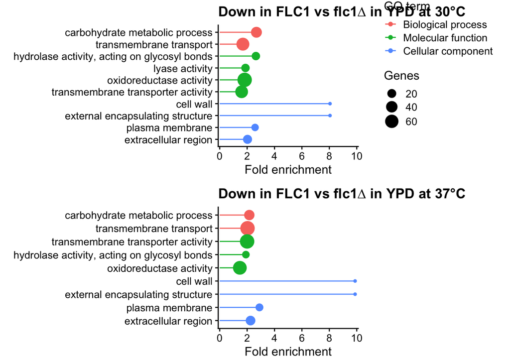

```r
GO_slim_37_down <- bind_rows(
  MF_slim_37_down,
  BP_slim_37_down,
  CC_slim_37_down) %>%
  janitor::clean_names() %>%
  mutate(
    go_type = factor(go_type, levels = c("BP", "MF", "CC"), labels = c("Biological process", "Molecular function", "Cellular component"))
  ) %>%
  group_by(go_type) %>%
  arrange(desc(fold_enrichment), .by_group = T)

GO_slim_37_down$name <- factor(GO_slim_37_down$name, levels = rev(GO_slim_37_down$name))


# Plot GO fold enrichment for down at 30°C
pGO_slim_30_down <- ggplot(
  data = GO_slim_30_down,
  aes(x = 0, xend = fold_enrichment, y = name, colour = go_type, fill = go_type)
) +
  geom_point(aes(x = fold_enrichment, y = name, size = result_count, fill = go_type)) +
  geom_segment() +
    labs(size="Genes", colour="GO term", fill = "GO term") +
    xlab("Fold enrichment") +
    ylab("") +
    scale_x_continuous(breaks = c(0,2,4,6,8,10), limits = c(0,10), expand = c(0.01,0.01))

# Plot GO fold enrichment for down at 37°C
pGO_slim_37_down <- ggplot(
  data = GO_slim_37_down,
  aes(x = 0, xend = fold_enrichment, y = name, colour = go_type, fill = go_type)
) +
  geom_point(aes(x = fold_enrichment, y = name, size = result_count, fill = go_type)) +
  geom_segment() +
    labs(size="Genes", colour="GO term", fill = "GO term") +
    xlab("Fold enrichment") +
    ylab("") +
    scale_x_continuous(breaks = c(0,2,4,6,8,10), limits = c(0,10), expand = c(0.01,0.01))

# Plot side-by-side
plegend <- get_legend(
  pGO_slim_30_down +
  theme(legend.box.margin = margin(2, 2, 2, 2),
        legend.justification = "top")
)
# add the legend to the row we made earlier. Give it one-third of
# the width of one plot (via rel_widths).
plot_grid(
  pGO_slim_30_down + theme(legend.position="none") + ggtitle("Down in FLC1 vs flc1∆ in YPD at 30°C"),
  plegend,
  pGO_slim_37_down + theme(legend.position="none") + ggtitle("Down in FLC1 vs flc1∆ in YPD at 37°C"),
  nrow = 2,
  rel_widths = c(1, .4),
  align = "v")
```

```r
# Open GO analysis for down regulated gene in WT vs flc1∆ at 30°C
MF_slim_30_up <- read_tsv(
  here("results/GOanalysis/GO_WTvsdelta_30C_YPD_up2x_FDR5_molecular_function_slim.tsv")
) %>%
  mutate(
    Comparison = "WTvsdelta_30C_YPD",
    GO_type = "MF",
    DEG = "up"
  )
BP_slim_30_up <- read_tsv(
  here("results/GOanalysis/GO_WTvsdelta_30C_YPD_up2x_FDR5_biological_process_slim.tsv")
) %>%
  mutate(
    Comparison = "WTvsdelta_30C_YPD",
    GO_type = "BP", ,
    DEG = "up"
  )
CC_slim_30_up <- read_tsv(
  here("results/GOanalysis/GO_WTvsdelta_30C_YPD_up2x_FDR5_cellular_component_slim.tsv")
) %>%
  mutate(
    Comparison = "WTvsdelta_30C_YPD",
    GO_type = "CC", ,
    DEG = "up"
  )
GO_slim_30_up <- bind_rows(
  MF_slim_30_up,
  BP_slim_30_up,
  CC_slim_30_up) %>%
  janitor::clean_names() %>%
  mutate(
    go_type = factor(go_type, levels = c("BP", "MF", "CC"), labels = c("Biological process", "Molecular function", "Cellular component"))
  ) %>%
  group_by(go_type) %>%
  arrange(desc(fold_enrichment), .by_group = T)

GO_slim_30_up$name <- factor(GO_slim_30_up$name, levels = rev(GO_slim_30_up$name))


# Open GO analysis for upregulated gene in WT vs flc1∆ at 37°C

MF_slim_37_up <- read_tsv(
  here("results/GOanalysis/GO_WTvsdelta_37C_YPD_up2x_FDR5_molecular_function_slim.tsv")
) %>%
  mutate(
    Comparison = "WTvsdelta_37C_YPD",
    GO_type = "MF",
    DEG = "up"
  )
BP_slim_37_up <- read_tsv(
  here("results/GOanalysis/GO_WTvsdelta_37C_YPD_up2x_FDR5_biological_process_slim.tsv")
) %>%
  mutate(
    Comparison = "WTvsdelta_37C_YPD",
    GO_type = "BP",
    DEG = "up"
  )
CC_slim_37_up <- read_tsv(
  here("results/GOanalysis/GO_WTvsdelta_37C_YPD_up2x_FDR5_cellular_component_slim.tsv")
) %>%
  mutate(
    Comparison = "WTvsdelta_37C_YPD",
    GO_type = "CC",
    DEG = "up"
  )
```

```r
GO_slim_37_up <- bind_rows(
  MF_slim_37_up,
  BP_slim_37_up,
  CC_slim_37_up) %>%
  janitor::clean_names() %>%
  mutate(
    go_type = factor(go_type, levels = c("BP", "MF", "CC"), labels = c("Biological process", "Molecular function", "Cellular component"))
  ) %>%
  group_by(go_type) %>%
  arrange(desc(fold_enrichment), .by_group = T)

GO_slim_37_up$name <- factor(GO_slim_37_up$name, levels = rev(GO_slim_37_up$name))


# Plot GO fold enrichment for up at 30°C
pGO_slim_30_up <- ggplot(
  data = GO_slim_30_up,
  aes(x = 0, xend = fold_enrichment, y = name, colour = go_type, fill = go_type)
) +
  geom_point(aes(x = fold_enrichment, y = name, size = result_count, fill = go_type)) +
  geom_segment() +
    labs(size="Genes", colour="GO term", fill = "GO term") +
    xlab("Fold enrichment") +
    ylab("")
    #scale_x_continuous(breaks = c(0,2,4,6,8,10), limits = c(0,10), expand = c(0.01,0.01))

# Plot GO fold enrichment for up at 37°C
pGO_slim_37_up <- ggplot(
  data = GO_slim_37_up,
  aes(x = 0, xend = fold_enrichment, y = name, colour = go_type, fill = go_type)
) +
  geom_point(aes(x = fold_enrichment, y = name, size = result_count, fill = go_type)) +
  geom_segment() +
    labs(size="Genes", colour="GO term", fill = "GO term") +
    xlab("Fold enrichment") +
    ylab("")
    scale_x_continuous(breaks = c(0,2,4,6,8,10), limits = c(0,10), expand = c(0.01,0.01))
```

```
## <ScaleContinuousPosition>
##  Range:
##  Limits:    0 --   10
```

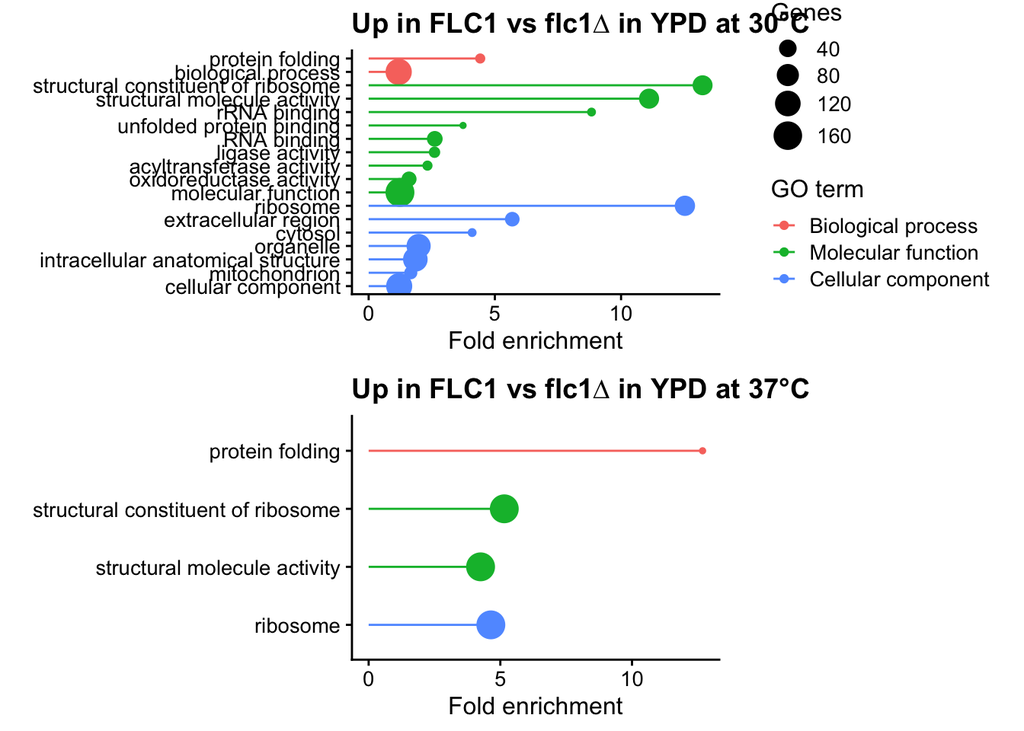

```r
# Plot side-by-side
plegend <- get_legend(
  pGO_slim_30_up +
  theme(legend.box.margin = margin(2, 2, 2, 2),
        legend.justification = "top")
)
# add the legend to the row we made earlier. Give it one-third of
# the width of one plot (via rel_widths).
plot_grid(
  pGO_slim_30_up + theme(legend.position="none") + ggtitle("Up in FLC1 vs flc1∆ in YPD at 30°C"),
  plegend,
  pGO_slim_37_up + theme(legend.position="none") + ggtitle("Up in FLC1 vs flc1∆ in YPD at 37°C"),
  nrow = 2,
  rel_widths = c(1, .4),
  align = "v")
```

```r
GOslim <- bind_rows(GO_slim_37_up, GO_slim_30_up, GO_slim_37_down, GO_slim_30_down) %>%
  mutate(comparison = factor(comparison,
                             levels = c("WTvsdelta_30C_YPD", "WTvsdelta_37C_YPD"),
                             labels = c("FLC1 vs flc1∆ at 30°C", "FLC1 vs flc1∆ at 37°C")),
         deg = factor(deg, levels = c("down", "up"), labels = c("up in flc1∆", "up in FLC1"))) %>%
  ungroup() %>%
  group_by(go_type, comparison) %>%
  arrange(desc(fold_enrichment), .by_group = T) %>%
  filter(!name %in% c("cellular component", "molecular function", "biological process", "organelle", "intracellular anatomical structure"))

GOslim$name <- factor(GOslim$name, levels = rev(unique(GOslim$name)))

NS_dataframe <- tibble(
name = c("rRNA binding", "unfolded protein binding", "RNA binding", "ligase activity", "acyltransferase activity", "oxidoreductase activity", "extracellular region", "cytosol", "mitochondrion", "lyase activity"),
comparison = c(rep("FLC1 vs flc1∆ at 37°C", times = 10)),
deg = c(rep("up in FLC1", times = 9), "up in flc1∆")
) %>%
  mutate(deg = factor(deg, levels = c("up in flc1∆", "up in FLC1")))

# Plot GO temrs without filling in 'NA' to make left and right plots match
#ggplot(
 # data = GOslim) +
  #geom_segment(aes(x = 0, xend = fold_enrichment, y = name, linetype = go_type)) +
  #scale_linetype_manual(values = c(1,2,3)) +
  #ggnewscale::new_scale_color() +
  #geom_point(aes(x = fold_enrichment, y = name, size = result_count, colour = deg)) +
  #scale_colour_manual(values = c("darkred", "darkblue")) +
   # labs(size="Number of Genes", linetype="GO term", colour = "Gene Expression") +
  #  xlab("Fold enrichment") +
   # ylab("") +
    #scale_x_continuous(breaks = c(0,2,4,6,8,10, 12, 14), limits = c(0,14), expand = c(0.01,0.01)) +
    #facet_wrap2(deg~comparison, scales = "free_y", axes = "all") +
    #theme(strip.text = element_text(colour = "white"),
     #     axis.text.y = element_text(size = 10, colour = "black"),
      #    axis.text.x = element_text(size = 10, colour = "black"),
       #   axis.title.x = element_text(size = 12, colour = "black"),
        #  legend.title = element_text(size = 12, colour = "black"),
         # legend.text = element_text(size = 10, colour = "black"),
          #legend.justification = "top",
          #legend.spacing.y = unit(1.0, 'cm'),
          #legend.box.margin = margin(t = 0, r = 0, b = 0, l = 1, unit = 'cm')) +
 # guides(linetype = guide_legend(order=1),
  #       colour = guide_legend(order=2),
   #      size = guide_legend(order=3))

#ggsave(here("GOanalysis_WTvsDelta_YPD_30C_37C.png"), height = 5, width = 12, dpi = 1000, bg = "white")
```

[figure not shown]

```r
# In this plot, GO term fold enrichment is plotted on the X axis and GO terms are plotted on the y axis. GO term type is indicated using different lines (solid, dashed, dotted) and number of genes per GO term is inficated using point size. Blue indicated GO termns up in FLC1 and red indicates GO termns up in flc1∆.
GO_slim_plot_WTvsdetla <- ggplot(
  data = GOslim) +
  geom_segment(aes(x = 0, xend = fold_enrichment, y = name, linetype = go_type)) +
  scale_linetype_manual(values = c(1,2,3)) +
  ggnewscale::new_scale_color() +
  geom_point(aes(x = fold_enrichment, y = name, size = result_count, colour = deg)) +
  scale_colour_manual(values = c("darkred", "darkblue")) +
    labs(size="Number of Genes", linetype="GO term", colour = "Gene Expression") +
    xlab("Fold enrichment") +
    ylab("") +
    scale_x_continuous(breaks = c(0,2,4,6,8,10, 12, 14), limits = c(0,14), expand = c(0.01,0.01)) +
    #ggforce::facet_col(deg~comparison, scales = "free_y", space = "free") +
    theme(axis.text.x = element_text(size = 3))

# Add in 'NA' symbols to make left and right plots symmertcial. The ggh4x package has a nice facet function that allows you to display the axes of all plots
GO_slim_plot_WTvsdetla +
  geom_text(data = NS_dataframe, aes(x = 0.8, y = name, label = "NA"), size = 3) +
    facet_grid2(deg~comparison, scale = "free_y", space = "free",  axes = "all") +
    theme(strip.text.y = element_blank(),
          strip.text.x = element_text(size = 16, colour = "black", family="Arial"),
          axis.text.y = element_text(size = 14, colour = "black", family="Arial"),
          axis.text.x = element_text(size = 14, colour = "black", family="Arial"),
          axis.title.x = element_text(size = 16, colour = "black", family="Arial"),
          legend.title = element_text(size = 16, colour = "black", family="Arial"),
          legend.text = element_text(size = 14, colour = "black", family="Arial"),
          panel.spacing.x = unit(4, "lines"),
          legend.justification = "top",
          legend.spacing.y = unit(1.0, 'cm'),
          legend.box.margin = margin(t = -0.5, r = 0, b = 0, l = 2, unit = 'cm')
          ) +
  guides(linetype = guide_legend(order=1),
         colour = guide_legend(order=2),
         size = guide_legend(order=3))
```

```r
#ggsave(here("GOanalysis_WTvsDelta_YPD_30C_37C_grid.png"), height = 8, width = 16, dpi = 1000, bg = "white")
```

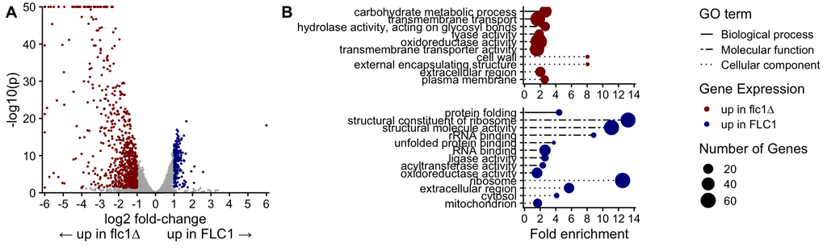

```r
GOslim_WTvsdelat_YPD_30 <- ggplot(
  data = GOslim %>% filter(comparison == "FLC1 vs flc1∆ at 30°C")) +
  geom_segment(aes(x = 0, xend = fold_enrichment, y = name, linetype = go_type)) +
  scale_linetype_manual(values = c("solid", "twodash", "dotted")) +
  ggnewscale::new_scale_color() +
  geom_point(aes(x = fold_enrichment, y = name, size = result_count, colour = deg)) +
  scale_colour_manual(values = c("darkred", "darkblue")) +
    labs(size="Number of Genes", linetype="GO term", colour = "Gene Expression") +
    xlab("Fold enrichment") +
    ylab("") +
    scale_x_continuous(breaks = c(0,2,4,6,8,10, 12, 14), limits = c(0,14), expand = c(0.01,0.01)) +
    facet_grid2(deg~., scales = "free_y", axes = "all", space = "free") +
    theme(strip.text = element_text(colour = "white"),
          axis.text.y = element_text(size = 10, colour = "black"),
          axis.text.x = element_text(size = 10, colour = "black"),
          axis.title.x = element_text(size = 12, colour = "black"),
          legend.title = element_text(size = 12, colour = "black"),
          legend.text = element_text(size = 10, colour = "black"),
          legend.justification = "top",
          legend.spacing.y = unit(0.3, 'cm'),
          legend.box.margin = margin(t = 0, r = 0, b = 0, l = 1, unit = 'cm')) +
  guides(linetype = guide_legend(order=1),
         colour = guide_legend(order=2),
         size = guide_legend(order=3))

#ggsave(here("GOanalysis_37Cvs30C_WT_vertical.png"), height = 5, width = 7, dpi = 1000, bg = "white")


Volcano_GOterm_30 <- cowplot::plot_grid(volcano_WTvsdelta_30C_YPD, GOslim_WTvsdelat_YPD_30, rel_widths = c(1:4),
                                        labels = c('A', 'B'))
Volcano_GOterm_30
```

```r
#ggsave(here("results/figures/WTvsdelta_YPD_30_volcano_GOterm.png"),Volcano_GOterm_30, height = 4.5, width = 12, dpi = 1000, bg = "white")
```

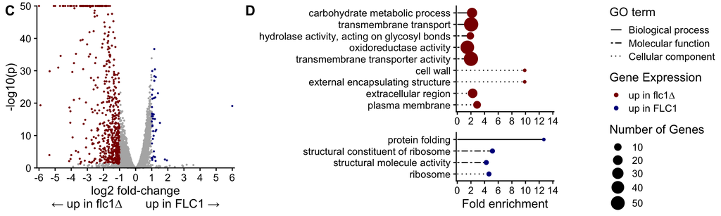

```r
GOslim_WTvsdelat_YPD_37 <- ggplot(
  data = GOslim %>% filter(comparison == "FLC1 vs flc1∆ at 37°C")) +
  geom_segment(aes(x = 0, xend = fold_enrichment, y = name, linetype = go_type)) +
  scale_linetype_manual(values = c("solid", "twodash", "dotted")) +
  ggnewscale::new_scale_color() +
  geom_point(aes(x = fold_enrichment, y = name, size = result_count, colour = deg)) +
  scale_colour_manual(values = c("darkred", "darkblue")) +
    labs(size="Number of Genes", linetype="GO term", colour = "Gene Expression") +
    xlab("Fold enrichment") +
    ylab("") +
    scale_x_continuous(breaks = c(0,2,4,6,8,10, 12, 14), limits = c(0,14), expand = c(0.01,0.01)) +
    facet_grid2(deg~., scales = "free_y", axes = "all", space = "free") +
    theme(strip.text = element_text(colour = "white"),
          axis.text.y = element_text(size = 10, colour = "black"),
          axis.text.x = element_text(size = 10, colour = "black"),
          axis.title.x = element_text(size = 12, colour = "black"),
          legend.title = element_text(size = 12, colour = "black"),
          legend.text = element_text(size = 10, colour = "black"),
          legend.justification = "top",
          legend.spacing.y = unit(0.3, 'cm'),
          legend.box.margin = margin(t = 0, r = 0, b = 0, l = 1, unit = 'cm')) +
  guides(linetype = guide_legend(order=1),
         colour = guide_legend(order=2),
         size = guide_legend(order=3))

#ggsave(here("GOanalysis_37Cvs37C_WT_vertical.png"), height = 5, width = 7, dpi = 1000, bg = "white")


Volcano_GOterm_37 <- cowplot::plot_grid(volcano_WTvsdelta_37C_YPD, GOslim_WTvsdelat_YPD_37, rel_widths = c(1:4), labels = c('C', 'D'))
Volcano_GOterm_37
```

```r
#ggsave(here("results/figures/WTvsdelta_YPD_37_volcano_GOterm.png"),Volcano_GOterm_37, height = 4.5, width = 12, dpi = 1000, bg = "white")
```

# Create a list of genes to highlight on volcano plots

Ca2+ channels and pumps: - CNAG_01232 = PMC1 (Calcium pump) - CNAG_01704 = McSc channel - CNAG_06060 = Ca2+ dependant channel (Csc1 family) - CNAG_07538 = Ca2+/Na+ exchanger (IPR004837 family) - CNAG_01208 = CCH1 - CNAG_00025 = VCX1 - CNAG_00107 = MCU family - CNAG_03805 = VCX1

Cell wall synthesis genes: - CNAG_01230 = chitin deacetylase 2 - CNAG_06501 = GAS1 - CNAG_05818 = CHS5 - CNAG_02217 = CHS7 - CNAG_06508 = FKS1 - CNAG_07499 = CHS8 - CNAG_02225 = EXG104 - CNAG_05799 = CDA1 (chitin deacetylase 1) - CNAG_06031 = KRE63 - CNAG_06835 = KRE61 - CNAG_00546 = CHS4 - CNAG_06726 = CSR3 - CNAG_06336 = BGL2 - CNAG_06291 = polysaccharide deacetylase (Cda4/Fpd1) - CNAG_00596 = UTR2 - CNAG_03412 = Chitinase

FLC1 and FLC2: - CNAG_00066 = FLC2 - CNAG_04283 = FLC1

Other interesing proteins: - CNAG_00979 = CTR4 - CNAG_00036 = SEC14-2 - CNAG_01446 = HSP12 - CNAG_03385 = PCL103 (cyclin) - CNAG_01562 = BLP4 - CNAG_02008 = OVA1 - CNAG_03464 = LAC2 - CNAG_03465 = LAC1 - CNAG_06347 = BLP2 - CNAG_06346 = BLP1 - CNAG_07701 = CTR1

# Venn diagrams of up and down regulated genes WT vs delta at 37°C and 30°C

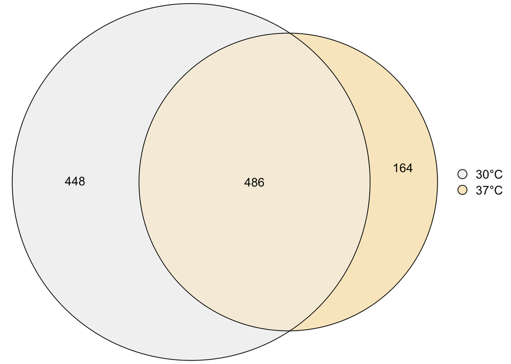

```r
# Turn into lists of genes
DGE_30 <- bind_rows(DEGdf_WT_down2x_FDR5_30, DEGdf_WT_up2x_FDR5_30) %>%
.$gene
DGE_37 <- bind_rows(DEGdf_WT_down2x_FDR5_37, DEGdf_WT_up2x_FDR5_37) %>%
.$gene

# Add to a list object with names to display on plot
euler_list <- list(
  '30°C' = DGE_30,
  '37°C' = DGE_37)

# Create the euler plot
eulerr_plot <- plot(
  euler(euler_list),
  quantities = TRUE,
  legend = TRUE,
  fills = c("grey95", "#F9E9C8"),
  fontsize = 20
  )

# Display eulerr
eulerr_plot
```

```r
DEGdf_WT_down2x_FDR5_37 %>% filter(!gene %in% DEGdf_WT_down2x_FDR5_30$gene)
```

```
## # A tibble: 153 × 6
##    gene       geneName baseMean log2FC stderror      padj
##    <chr>      <chr>       <dbl>  <dbl>    <dbl>     <dbl>
##  1 CNAG_01560 <NA>         3.89  -4.13    1.40  0.00791
##  2 CNAG_03797 <NA>        12.6   -3.57    0.760 0.0000132
##  3 CNAG_05278 <NA>         2.45  -3.43    1.51  0.0460
##  4 CNAG_07793 <NA>         4.55  -3.39    1.23  0.0139
##  5 CNAG_06911 <NA>         5.82  -3.16    1.03  0.00584
##  6 CNAG_05324 <NA>         5.02  -2.88    1.05  0.0138
##  7 CNAG_02489 <NA>        13.0   -2.87    0.652 0.0000456
##  8 CNAG_03551 <NA>         5.00  -2.87    1.07  0.0166
##  9 CNAG_02521 <NA>         4.54  -2.75    1.08  0.0240
## 10 CNAG_03842 <NA>         7.91  -2.58    0.829 0.00501
## # ℹ 143 more rows
```

Look for transcription factors in DEG at 30°C and 37°C

```r
# Read list of putative C.neoformans TFs from Jung et al. 2015
TFs <- read_csv(here("TFlist.csv")) %>%
  mutate(gene = paste("CNAG_", gene, sep = ""))
# Filter for TFs in DEGs
DEGdf_WT_down2x_FDR5_37 %>%
  filter(gene %in% TFs$gene)
```

```
## # A tibble: 16 × 6
##    gene       geneName baseMean log2FC stderror     padj
##    <chr>      <chr>       <dbl>  <dbl>    <dbl>    <dbl>
##  1 CNAG_04837 MLN1         10.2  -2.23    0.680 3.05e- 3
##  2 CNAG_04457 FZC30        36.7  -1.69    0.338 3.06e- 6
##  3 CNAG_04594 FZC27       182.   -1.65    0.167 2.05e-21
##  4 CNAG_00559 BZP3        663.   -1.45    0.127 1.14e-28
##  5 CNAG_01841 GLN3         22.8  -1.40    0.402 1.54e- 3
##  6 CNAG_05431 RIM101      751.   -1.35    0.114 2.26e-30
##  7 CNAG_02877 FZC51       192.   -1.27    0.166 3.50e-13
##  8 CNAG_05861 FKH101      357.   -1.26    0.142 1.36e-17
##  9 CNAG_06276 CEP3         26.6  -1.23    0.382 3.55e- 3
## 10 CNAG_04804 SRE1        436.   -1.21    0.150 1.30e-14
## 11 CNAG_02516 HLH5        181.   -1.17    0.165 1.60e-11
## 12 CNAG_01977 <NA>         20.5  -1.17    0.421 1.33e- 2
## 13 CNAG_03894 PDR802       48.3  -1.14    0.322 1.27e- 3
## 14 CNAG_00239 YAP1        263.   -1.04    0.154 1.38e-10
## 15 CNAG_00871 CLR3         51.6  -1.02    0.273 6.13e- 4
## 16 CNAG_03998 RLM1        200.   -1.00    0.160 3.29e- 9
```

```r
# Filter for TFs in DEGs
DEGdf_WT_down2x_FDR5_30 %>%
  filter(gene %in% TFs$gene)
```

```
## # A tibble: 15 × 6
##    gene       geneName baseMean log2FC stderror     padj
##    <chr>      <chr>       <dbl>  <dbl>    <dbl>    <dbl>
##  1 CNAG_04837 MLN1         6.67  -3.11    0.933 3.21e- 3
##  2 CNAG_02877 FZC51      102.    -2.99    0.276 1.60e-25
##  3 CNAG_04036 <NA>        14.4   -2.30    0.617 8.43e- 4
##  4 CNAG_00828 SIP401     146.    -2.20    0.235 3.20e-19
##  5 CNAG_03346 BZP4        37.1   -2.02    0.358 1.75e- 7
##  6 CNAG_04594 FZC27      168.    -1.68    0.215 1.42e-13
##  7 CNAG_00791 HLH1       276.    -1.50    0.197 5.89e-13
##  8 CNAG_02516 HLH5       139.    -1.36    0.228 3.36e- 8
##  9 CNAG_02476 YRM101      37.9   -1.28    0.345 8.73e- 4
## 10 CNAG_00559 BZP3       498.    -1.24    0.179 9.28e-11
## 11 CNAG_02774 MAL13      169.    -1.21    0.199 1.84e- 8
## 12 CNAG_01551 GAT201     149.    -1.14    0.254 4.28e- 5
## 13 CNAG_00156 SP1        311.    -1.14    0.174 9.24e-10
## 14 CNAG_03894 PDR802      31.2   -1.10    0.445 3.53e- 2
## 15 CNAG_00871 CLR3        22.9   -1.01    0.412 3.66e- 2
```

```r
# Filter for TFs in DEGs
DEGdf_WT_up2x_FDR5_37 %>%
  filter(gene %in% TFs$gene)
```

```
## # A tibble: 0 × 6
## # ℹ 6 variables: gene <chr>, geneName <chr>, baseMean <dbl>, log2FC <dbl>,
## #   stderror <dbl>, padj <dbl>
```

```r
# Filter for TFs in DEGs
DEGdf_WT_up2x_FDR5_30 %>%
  filter(gene %in% TFs$gene)
```

```
## # A tibble: 0 × 6
## # ℹ 6 variables: gene <chr>, geneName <chr>, baseMean <dbl>, log2FC <dbl>,
## #   stderror <dbl>, padj <dbl>
```